# Experiment 2 Analysis

```r
##OLD#######################

#1) Are there significant differences between A, B and X when asked in their original block 1 and in the test phase
#t.test(A1A$responseR1, train$responseR1[train$blockNr == "Block1"], alternative = "two.sided", paired = FALSE) #no sign
#t.test(B1A$responseR1, train$responseR2[train$blockNr == "Block1"], alternative = "two.sided", paired = FALSE) #sign diff, increase
#t.test(X1A$responseR2, train$responseR3[train$blockNr == "Block1"], alternative = "two.sided", paired = FALSE) #sign diff, increase


#2) Are there sign differences between A, B and X when asked in block 3 and in the test phase
#t.test(A3A$responseR1, train$responseR1[train$blockNr == "Block3"], alternative = "two.sided", paired = FALSE) #sign diff, increase
#t.test(B3A$responseR1, train$responseR2[train$blockNr == "Block3"], alternative = "two.sided", paired = FALSE) #no diff
#t.test(X3A$responseR2, train$responseR3[train$blockNr == "Block3"], alternative = "two.sided", paired = FALSE) #sign diff, increase         (DIFF FROM 1)
#there is a significant difference for 2/3 cues in both the first and the third block. This seems to point to the Van Hamme Wasserman model.

#3) Is there a sign difference between the C value and that of A B and X in the test phase
#t.test(CA$responseR1, train$responseR1[train$blockNr == "Block3"], alternative = "two.sided", paired = FALSE) #sign diff, score to C is lower
#t.test(CA$responseR1, train$responseR2[train$blockNr == "Block3"], alternative = "two.sided", paired = FALSE) #no sign diff
#t.test(CA$responseR1, train$responseR3[train$blockNr == "Block3"], alternative = "two.sided", paired = FALSE) #no sign diff                 (DIFF FROM 1)


#t.test(CA$responseR1, train$responseR1[train$blockNr == "Block1"], alternative = "two.sided", paired = FALSE) #sign diff, score to C is lower
#t.test(CA$responseR1, train$responseR2[train$blockNr == "Block1"], alternative = "two.sided", paired = FALSE) #no sign diff
#t.test(CA$responseR1, train$responseR3[train$blockNr == "Block1"], alternative = "two.sided", paired = FALSE) #no sign diff                 (DIFF FROM 1)
#here there is only a sign difference between cue A in both blocks and C. The fact that there is no significant difference is not really in line with any of the two models


#4) Is there a difference between the ratings to fossil and those to diamond?
#t.test(A1A$responseR1, A1F$responseR1, alternative = "two.sided", paired = FALSE) #not sign
#t.test(B1A$responseR1, B1F$responseR1, alternative = "two.sided", paired = FALSE) #not sign, (margnially fever lower than allergy)          (DIFF FROM 1)
#t.test(X1A$responseR2, X1F$responseR2, alternative = "two.sided", paired = FALSE) #sign, lower score on the fever than on allergic
#t.test(CA$responseR1, CF$responseR1, alternative = "two.sided", paired = FALSE)   #no sign (makes sense! The cue is new)
#t.test(A3A$responseR1, A3F$responseR1, alternative = "two.sided", paired = FALSE) #sign, lower score on the fever than on allergic
#t.test(B3A$responseR1, B3F$responseR1, alternative = "two.sided", paired = FALSE) #not sign                                                 (DIFF FROM 1)
#t.test(X3A$responseR2, X3F$responseR2, alternative = "two.sided", paired = FALSE) #sign, lower score on the fever than on allergic          (DIFF FROM 1)

# most cues show a lower rating for fever (the new cue) than for allergic. Others are not significant.
```

What I now want to do is split this into the seperate conditions

```r
testFSplit <- aggregate(list(testF$responseR1, testF$responseR2), list(testF$CondFirstBlock, testF$CondThirdBlock, testF$Trial), mean, na.rm = T)
colnames(testFSplit) <- c("Cond1", "Cond3", "Trial", "Response1", "Response2")
testASplit <- aggregate(list(testA$responseR1, testA$responseR2), list(testA$CondFirstBlock, testA$CondThirdBlock, testA$Trial), mean, na.rm = T)
colnames(testASplit) <- c("Cond1", "Cond3", "Trial", "Response1", "Response2")

#for each item we want the trials that belong to the first or third cue, and then take those purely from one condition

#X000
X1F000 <- testFSplit[which( (testFSplit$Trial == 2 | testFSplit$Trial == 4 | testFSplit$Trial == 6) & testFSplit$Cond1 == "0") ,]
avgX1F000 <- mean(X1F000$Response2, na.rm = T)
X1A000 <- testASplit[which( (testASplit$Trial == 1 | testASplit$Trial == 3 | testASplit$Trial == 5) & testASplit$Cond1 == "0") ,]
avgX1A000 <- mean(X1A000$Response2, na.rm = T)

X3F000 <- testFSplit[which( (testFSplit$Trial == 8 | testFSplit$Trial == 10) & testFSplit$Cond3 == "0"),]
avgX3F000 <- mean(X3F000$Response2, na.rm = T)
X3A000 <- testASplit[which( (testASplit$Trial == 7 | testASplit$Trial == 9) & testASplit$Cond3 == "0"),]
avgX3A000 <- mean(X3A000$Response2, na.rm = T)

#X050
X1F050 <- testFSplit[which( (testFSplit$Trial == 2 | testFSplit$Trial == 4 | testFSplit$Trial == 6) & testFSplit$Cond1 == "50") ,]
avgX1F050 <- mean(X1F050$Response2, na.rm = T)
X1A050 <- testASplit[which( (testASplit$Trial == 1 | testASplit$Trial == 3 | testASplit$Trial == 5) & testASplit$Cond1 == "50") ,]
avgX1A050 <- mean(X1A050$Response2, na.rm = T)

X3F050 <- testFSplit[which( (testFSplit$Trial == 8 | testFSplit$Trial == 10) & testFSplit$Cond3 == "50"),]
avgX3F050 <- mean(X3F050$Response2, na.rm = T)
X3A050 <- testASplit[which( (testASplit$Trial == 7 | testASplit$Trial == 9) & testASplit$Cond3 == "50"),]
avgX3A050 <- mean(X3A050$Response2, na.rm = T)

#X100
X1F100 <- testFSplit[which( (testFSplit$Trial == 2 | testFSplit$Trial == 4 | testFSplit$Trial == 6) & testFSplit$Cond1 == "100") ,]
avgX1F100 <- mean(X1F100$Response2, na.rm = T)
X1A100 <- testASplit[which( (testASplit$Trial == 1 | testASplit$Trial == 3 | testASplit$Trial == 5) & testASplit$Cond1 == "100") ,]
avgX1A100 <- mean(X1A100$Response2, na.rm = T)

X3F100 <- testFSplit[which( (testFSplit$Trial == 8 | testFSplit$Trial == 10) & testFSplit$Cond3 == "100"),]
avgX3F100 <- mean(X3F100$Response2, na.rm = T)
X3A100 <- testASplit[which( (testASplit$Trial == 7 | testASplit$Trial == 9) & testASplit$Cond3 == "100"),]
avgX3A100 <- mean(X3A100$Response2, na.rm = T)

#######################################
#A000
A1F000 <- testFSplit[which( (testFSplit$Trial == 2 ) & testFSplit$Cond1 == "0") ,]
avgA1F000 <- mean(A1F000$Response1, na.rm = T)
A1A000 <- testASplit[which( (testASplit$Trial == 1) & testASplit$Cond1 == "0") ,]
avgA1A000 <- mean(A1A000$Response1, na.rm = T)

A3F000 <- testFSplit[which( (testFSplit$Trial == 8) & testFSplit$Cond3 == "0"),]
avgA3F000 <- mean(A3F000$Response1, na.rm = T)
A3A000 <- testASplit[which( (testASplit$Trial == 7) & testASplit$Cond3 == "0"),]
avgA3A000 <- mean(A3A000$Response1, na.rm = T)

#A050
A1F050 <- testFSplit[which( (testFSplit$Trial == 2) & testFSplit$Cond1 == "50") ,]
avgA1F050 <- mean(A1F050$Response1, na.rm = T)
A1A050 <- testASplit[which( (testASplit$Trial == 1) & testASplit$Cond1 == "50") ,]
avgA1A050 <- mean(A1A050$Response1, na.rm = T)

A3F050 <- testFSplit[which( (testFSplit$Trial == 8) & testFSplit$Cond3 == "50"),]
avgA3F050 <- mean(A3F050$Response1, na.rm = T)
A3A050 <- testASplit[which( (testASplit$Trial == 7) & testASplit$Cond3 == "50"),]
avgA3A050 <- mean(A3A050$Response1, na.rm = T)

#A100
A1F100 <- testFSplit[which( (testFSplit$Trial == 2) & testFSplit$Cond1 == "100") ,]
avgA1F100 <- mean(A1F100$Response1, na.rm = T)
A1A100 <- testASplit[which( (testASplit$Trial == 1) & testASplit$Cond1 == "100") ,]
avgA1A100 <- mean(A1A100$Response1, na.rm = T)

A3F100 <- testFSplit[which( (testFSplit$Trial == 8) & testFSplit$Cond3 == "100"),]
avgA3F100 <- mean(A3F100$Response1, na.rm = T)
A3A100 <- testASplit[which( (testASplit$Trial == 7) & testASplit$Cond3 == "100"),]
avgA3A100 <- mean(A3A100$Response1, na.rm = T)

#######################################

#B000
B1F000 <- testFSplit[which( (testFSplit$Trial == 4) & testFSplit$Cond1 == "0") ,]
avgB1F000 <- mean(B1F000$Response1, na.rm = T)
B1A000 <- testASplit[which( (testASplit$Trial == 3) & testASplit$Cond1 == "0") ,]
avgB1A000 <- mean(B1A000$Response1, na.rm = T)

B3F000 <- testFSplit[which( (testFSplit$Trial == 10) & testFSplit$Cond3 == "0"),]
avgB3F000 <- mean(B3F000$Response1, na.rm = T)
B3A000 <- testASplit[which( (testASplit$Trial == 9) & testASplit$Cond3 == "0"),]
avgB3A000 <- mean(B3A000$Response1, na.rm = T)

#B050
B1F050 <- testFSplit[which( (testFSplit$Trial == 4) & testFSplit$Cond1 == "50") ,]
avgB1F050 <- mean(B1F050$Response1, na.rm = T)
B1A050 <- testASplit[which( (testASplit$Trial == 3) & testASplit$Cond1 == "50") ,]
avgB1A050 <- mean(B1A050$Response1, na.rm = T)

B3F050 <- testFSplit[which( (testFSplit$Trial == 10) & testFSplit$Cond3 == "50"),]
avgB3F050 <- mean(B3F050$Response1, na.rm = T)
B3A050 <- testASplit[which( (testASplit$Trial == 9) & testASplit$Cond3 == "50"),]
avgB3A050 <- mean(B3A050$Response1, na.rm = T)

#B100
B1F100 <- testFSplit[which( (testFSplit$Trial == 4) & testFSplit$Cond1 == "100") ,]
avgB1F100 <- mean(B1F100$Response1, na.rm = T)
B1A100 <- testASplit[which( (testASplit$Trial == 3) & testASplit$Cond1 == "100") ,]
avgB1A100 <- mean(B1A100$Response1, na.rm = T)

B3F100 <- testFSplit[which( (testFSplit$Trial == 10) & testFSplit$Cond3 == "100"),]
avgB3F100 <- mean(B3F100$Response1, na.rm = T)
B3A100 <- testASplit[which( (testASplit$Trial == 9) & testASplit$Cond3 == "100"),]
avgB3A100 <- mean(B3A100$Response1, na.rm = T)


#as C was never asked before we cannot really compare it over conditions
#C
CF <- testF[which(testF$Trial == 6),]
avgCF <- mean(CF$responseR1, na.rm = T)
CA <- testA[which(testA$Trial == 5),]
avgCA <- mean(CA$responseR1, na.rm = T)


Cue <- c("A1","A1","A1", "B1", "B1", "B1", "X1", "X1", "X1", "C", "A3", "A3", "A3", "B3", "B3", "B3", "X3", "X3", "X3")
Cond <- c("0", "50", "100", "0", "50", "100", "0", "50", "100", "NA", "0", "50", "100", "0", "50", "100", "0", "50", "100")
Allergy1 <- c(avgA1A000, avgA1A050, avgA1A100, avgB1A000, avgB1A050, avgB1A100, avgX1A000, avgX1A050, avgX1A100, avgCA, avgA3A000, avgA3A050, avgA3A100, avgB3A000, avgB3A050, avgB3A100, avgX3A000, avgX3A050, avgX3A100)
Fever1 <- c(avgA1F000, avgA1F050, avgA1F100, avgB1F000, avgB1F050, avgB1F100, avgX1F000, avgX1F050, avgX1F100, avgCF, avgA3F000, avgA3F050, avgA3F100, avgB3F000, avgB3F050, avgB3F100, avgX3F000, avgX3F050, avgX3F100)
Phase1Split <- data.frame(Cue, Cond, Allergy1, Fever1)
Phase1Split
```

```
##    Cue Cond Allergy1   Fever1
## 1   A1    0 2.400000 1.266667
## 2   A1   50 4.166667 4.250000
## 3   A1  100 6.900000 4.100000
## 4   B1    0 3.500000 2.933333
## 5   B1   50 5.666667 4.250000
## 6   B1  100 4.600000 4.400000
## 7   X1    0 4.330556 3.655556
## 8   X1   50 4.305556 3.194444
## 9   X1  100 4.533333 3.433333
## 10   C   NA 2.842105 2.578947
## 11  A3    0 6.900000 3.850000
## 12  A3   50 4.200000 2.200000
## 13  A3  100 5.000000 4.333333
## 14  B3    0 3.250000 2.450000
## 15  B3   50 4.000000 4.400000
## 16  B3  100 4.500000 3.333333
## 17  X3    0 4.150000 2.625000
## 18  X3   50 5.300000 3.100000
## 19  X3  100 3.250000 2.333333
```

```r
#and now to add on to that, the original ones

#now that we know what was asked when in the training phase
ABl1000 <- mean(train$responseR1[train$blockNr == "Block1" & train$Cond == "0"& train$Trial == 16], na.rm = T)
ABl1050 <- mean(train$responseR1[train$blockNr == "Block1" & train$Cond == "50"& train$Trial == 16], na.rm = T)
ABl1100 <- mean(train$responseR1[train$blockNr == "Block1" & train$Cond == "100"& train$Trial == 16], na.rm = T)

BBl1000 <- mean(train$responseR2[train$blockNr == "Block1" & train$Cond == "0"& train$Trial == 16], na.rm = T)
BBl1050 <- mean(train$responseR2[train$blockNr == "Block1" & train$Cond == "50"& train$Trial == 16], na.rm = T)
BBl1100 <- mean(train$responseR2[train$blockNr == "Block1" & train$Cond == "100"& train$Trial == 16], na.rm = T)

XBl1000 <- mean(train$responseR3[train$blockNr == "Block1" & train$Cond == "0"& train$Trial == 16], na.rm = T)
XBl1050 <- mean(train$responseR3[train$blockNr == "Block1" & train$Cond == "50"& train$Trial == 16], na.rm = T)
XBl1100 <- mean(train$responseR3[train$blockNr == "Block1" & train$Cond == "100"& train$Trial == 16], na.rm = T)

ABl3000 <- mean(train$responseR1[train$blockNr == "Block3" & train$Cond == "0"& train$Trial == 16], na.rm = T)
ABl3050 <- mean(train$responseR1[train$blockNr == "Block3" & train$Cond == "50"& train$Trial == 16], na.rm = T)
ABl3100 <- mean(train$responseR1[train$blockNr == "Block3" & train$Cond == "100"& train$Trial == 16], na.rm = T)

BBl3000 <- mean(train$responseR2[train$blockNr == "Block3" & train$Cond == "0"& train$Trial == 16], na.rm = T)
BBl3050 <- mean(train$responseR2[train$blockNr == "Block3" & train$Cond == "50"& train$Trial == 16], na.rm = T)
BBl3100 <- mean(train$responseR2[train$blockNr == "Block3" & train$Cond == "100"& train$Trial == 16], na.rm = T)

XBl3000 <- mean(train$responseR3[train$blockNr == "Block3" & train$Cond == "0"& train$Trial == 16], na.rm = T)
XBl3050 <- mean(train$responseR3[train$blockNr == "Block3" & train$Cond == "50"& train$Trial == 16], na.rm = T)
XBl3100 <- mean(train$responseR3[train$blockNr == "Block3" & train$Cond == "100"& train$Trial == 16], na.rm = T)


Original <- c(ABl1000, ABl1050, ABl1100, BBl1000, BBl1050, BBl1100, XBl1000, XBl1050, XBl1100, "NA", ABl3000, ABl3050, ABl3100, BBl3000, BBl3050, BBl3100, XBl3000, XBl3050, XBl3100)
Phase1Split$Original <- as.numeric(Original)
Phase1Split
```

```
##    Cue Cond Allergy1   Fever1  Original
## 1   A1    0 2.400000 1.266667 1.6250000
## 2   A1   50 4.166667 4.250000 4.2000000
## 3   A1  100 6.900000 4.100000 5.4285714
## 4   B1    0 3.500000 2.933333 2.6250000
## 5   B1   50 5.666667 4.250000 1.2500000
## 6   B1  100 4.600000 4.400000 0.7142857
## 7   X1    0 4.330556 3.655556 2.0000000
## 8   X1   50 4.305556 3.194444 2.7500000
## 9   X1  100 4.533333 3.433333 1.1428571
## 10   C   NA 2.842105 2.578947        NA
## 11  A3    0 6.900000 3.850000 3.2857143
## 12  A3   50 4.200000 2.200000 4.5714286
## 13  A3  100 5.000000 4.333333 4.5000000
## 14  B3    0 3.250000 2.450000 3.0000000
## 15  B3   50 4.000000 4.400000 2.0000000
## 16  B3  100 4.500000 3.333333 1.6666667
## 17  X3    0 4.150000 2.625000 3.5714286
## 18  X3   50 5.300000 3.100000 3.0000000
## 19  X3  100 3.250000 2.333333 0.3333333
```

In this table we now see each cue, which condition they were originally asked in, their scores to allergy in the test phase, their scores to fever in the test phase, and their score in their original block.

First of all is there even a significan difference between the scores given to the different conditions for allergy?

```r
t.test(A1A000$Response1, A1A050$Response1, alternative = "two.sided", paired = FALSE) #no diff
```

```
##
##  Welch Two Sample t-test
##
## data:  A1A000$Response1 and A1A050$Response1
## t = -4.0769, df = 1.3371, p-value = 0.1036
## alternative hypothesis: true difference in means is not equal to 0
## 95 percent confidence interval:
##  -4.868854  1.335520
## sample estimates:
## mean of x mean of y
##  2.400000  4.166667
```

```r
t.test(A1A050$Response1, A1A100$Response1, alternative = "two.sided", paired = FALSE) #sign diff, 100 higher than 050 for A (DIFF 1)
```

```
##
##  Welch Two Sample t-test
##
## data:  A1A050$Response1 and A1A100$Response1
## t = -14.063, df = 1.6374, p-value = 0.01059
## alternative hypothesis: true difference in means is not equal to 0
## 95 percent confidence interval:
##  -3.774759 -1.691907
## sample estimates:
## mean of x mean of y
##  4.166667  6.900000
```

```r
t.test(A1A100$Response1, A1A000$Response1, alternative = "two.sided", paired = FALSE) #sign diff, 100 higher than 000 for A (DIFF 1)
```

```
##
##  Welch Two Sample t-test
##
## data:  A1A100$Response1 and A1A000$Response1
## t = 10.914, df = 1.1245, p-value = 0.04443
## alternative hypothesis: true difference in means is not equal to 0
## 95 percent confidence interval:
##  0.4513242 8.5486758
## sample estimates:
## mean of x mean of y
##       6.9       2.4
```

```r
t.test(B1A000$Response1, B1A050$Response1, alternative = "two.sided", paired = FALSE) #no diff
```

```
##
##  Welch Two Sample t-test
##
## data:  B1A000$Response1 and B1A050$Response1
## t = -1.0796, df = 1.9729, p-value = 0.3945
## alternative hypothesis: true difference in means is not equal to 0
## 95 percent confidence interval:
##  -10.916547   6.583214
## sample estimates:
## mean of x mean of y
##  3.500000  5.666667
```

```r
t.test(B1A050$Response1, B1A100$Response1, alternative = "two.sided", paired = FALSE) #no diff
```

```
##
##  Welch Two Sample t-test
##
## data:  B1A050$Response1 and B1A100$Response1
## t = 0.51215, df = 1.937, p-value = 0.6609
## alternative hypothesis: true difference in means is not equal to 0
## 95 percent confidence interval:
##  -8.179736 10.313070
## sample estimates:
## mean of x mean of y
##  5.666667  4.600000
```

```r
t.test(B1A100$Response1, B1A000$Response1, alternative = "two.sided", paired = FALSE) #no diff
```

```
##
##  Welch Two Sample t-test
##
## data:  B1A100$Response1 and B1A000$Response1
## t = 0.50156, df = 1.9917, p-value = 0.6659
## alternative hypothesis: true difference in means is not equal to 0
## 95 percent confidence interval:
##  -8.374115 10.574115
## sample estimates:
## mean of x mean of y
##       4.6       3.5
```

```r
t.test(X1A000$Response2, X1A050$Response2, alternative = "two.sided", paired = FALSE) #no diff
```

```
##
##  Welch Two Sample t-test
##
## data:  X1A000$Response2 and X1A050$Response2
## t = 0.030656, df = 9.708, p-value = 0.9762
## alternative hypothesis: true difference in means is not equal to 0
## 95 percent confidence interval:
##  -1.799482  1.849482
## sample estimates:
## mean of x mean of y
##  4.330556  4.305556
```

```r
t.test(X1A050$Response2, X1A100$Response2, alternative = "two.sided", paired = FALSE) #no diff
```

```
##
##  Welch Two Sample t-test
##
## data:  X1A050$Response2 and X1A100$Response2
## t = -0.29622, df = 9.9507, p-value = 0.7732
## alternative hypothesis: true difference in means is not equal to 0
## 95 percent confidence interval:
##  -1.942264  1.486708
## sample estimates:
## mean of x mean of y
##  4.305556  4.533333
```

```r
t.test(X1A100$Response2, X1A000$Response2, alternative = "two.sided", paired = FALSE) #no diff
```

```
##
##  Welch Two Sample t-test
##
## data:  X1A100$Response2 and X1A000$Response2
## t = 0.24122, df = 9.8923, p-value = 0.8143
## alternative hypothesis: true difference in means is not equal to 0
## 95 percent confidence interval:
##  -1.673003  2.078559
## sample estimates:
## mean of x mean of y
##  4.533333  4.330556
```

So for block one there are is a sigificant difference in score between condtion 100-0 and 50-50 and between 100-0 and 75-25, where both 100-0 is scored higher on average. This makes sense, as in these two conditions A predicts an allergic reaction more often than B does.

```r
t.test(A3A000$Response1, A3A050$Response1, alternative = "two.sided", paired = FALSE) #no diff
```

```
##
##  Welch Two Sample t-test
##
## data:  A3A000$Response1 and A3A050$Response1
## t = 3.3489, df = 1.0312, p-value = 0.1787
## alternative hypothesis: true difference in means is not equal to 0
## 95 percent confidence interval:
##  -6.839007 12.239007
## sample estimates:
## mean of x mean of y
##       6.9       4.2
```

```r
t.test(A3A050$Response1, A3A100$Response1, alternative = "two.sided", paired = FALSE) #no diff
```

```
##
##  Welch Two Sample t-test
##
## data:  A3A050$Response1 and A3A100$Response1
## t = -0.37139, df = 1.312, p-value = 0.7614
## alternative hypothesis: true difference in means is not equal to 0
## 95 percent confidence interval:
##  -16.70907  15.10907
## sample estimates:
## mean of x mean of y
##       4.2       5.0
```

```r
t.test(A3A100$Response1, A3A000$Response1, alternative = "two.sided", paired = FALSE) #no diff          (DIFF FROM 1)
```

```
##
##  Welch Two Sample t-test
##
## data:  A3A100$Response1 and A3A000$Response1
## t = -0.94881, df = 1.005, p-value = 0.5161
## alternative hypothesis: true difference in means is not equal to 0
## 95 percent confidence interval:
##  -27.04696  23.24696
## sample estimates:
## mean of x mean of y
##       5.0       6.9
```

```r
t.test(B3A000$Response1, B3A050$Response1, alternative = "two.sided", paired = FALSE) #no diff
```

```
##
##  Welch Two Sample t-test
##
## data:  B3A000$Response1 and B3A050$Response1
## t = -0.318, df = 1.6778, p-value = 0.7856
## alternative hypothesis: true difference in means is not equal to 0
## 95 percent confidence interval:
##  -13.01416  11.51416
## sample estimates:
## mean of x mean of y
##      3.25      4.00
```

```r
t.test(B3A050$Response1, B3A100$Response1, alternative = "two.sided", paired = FALSE) #no diff
```

```
##
##  Welch Two Sample t-test
##
## data:  B3A050$Response1 and B3A100$Response1
## t = -0.24254, df = 1.1245, p-value = 0.845
## alternative hypothesis: true difference in means is not equal to 0
## 95 percent confidence interval:
##  -20.74338  19.74338
## sample estimates:
## mean of x mean of y
##       4.0       4.5
```

```r
t.test(B3A100$Response1, B3A000$Response1, alternative = "two.sided", paired = FALSE) #no diff          (DIFF FROM 1)
```

```
##
##  Welch Two Sample t-test
##
## data:  B3A100$Response1 and B3A000$Response1
## t = 0.92848, df = 1.312, p-value = 0.4919
## alternative hypothesis: true difference in means is not equal to 0
## 95 percent confidence interval:
##  -8.693166 11.193166
## sample estimates:
## mean of x mean of y
##      4.50      3.25
```

```r
t.test(X3A000$Response2, X3A050$Response2, alternative = "two.sided", paired = FALSE) #diff, 50 is scored higher than 000     (DIFF FROM 1)
```

```
##
##  Welch Two Sample t-test
##
## data:  X3A000$Response2 and X3A050$Response2
## t = -2.7296, df = 4.463, p-value = 0.04661
## alternative hypothesis: true difference in means is not equal to 0
## 95 percent confidence interval:
##  -2.27340163 -0.02659837
## sample estimates:
## mean of x mean of y
##      4.15      5.30
```

```r
t.test(X3A050$Response2, X3A100$Response2, alternative = "two.sided", paired = FALSE) #diff, 50 is scored higher than 100     (DIFF FROM 1)
```

```
##
##  Welch Two Sample t-test
##
## data:  X3A050$Response2 and X3A100$Response2
## t = 4.4705, df = 4.2131, p-value = 0.009827
## alternative hypothesis: true difference in means is not equal to 0
## 95 percent confidence interval:
##  0.8018299 3.2981701
## sample estimates:
## mean of x mean of y
##      5.30      3.25
```

```r
t.test(X3A100$Response2, X3A000$Response2, alternative = "two.sided", paired = FALSE) #no diff
```

```
##
##  Welch Two Sample t-test
##
## data:  X3A100$Response2 and X3A000$Response2
## t = -1.605, df = 5.9355, p-value = 0.1602
## alternative hypothesis: true difference in means is not equal to 0
## 95 percent confidence interval:
##  -2.2757365  0.4757365
## sample estimates:
## mean of x mean of y
##      3.25      4.15
```

The only things that significantly differ in the last block are the scores to allergic of X3 in the 50-50 and 75-25 conditon; and in the 75-25 and 100-0 condition. It’s significantly higher in the 75-25 condition, both when compared to the 100-0 and the 50-50 condition.

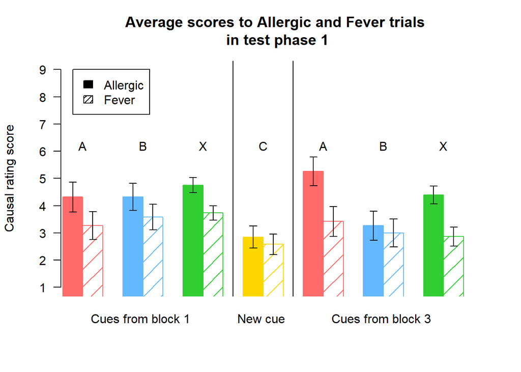

```r
SE_FA <- c(std.error(A1A$responseR1), std.error(A1F$responseR1),std.error(B1A$responseR1), std.error(B1F$responseR1), std.error(X1A$responseR2), std.error(X1F$responseR2), std.error(CA$responseR1), std.error(CF$responseR1), std.error(A3A$responseR1), std.error(A3F$responseR1),std.error(B3A$responseR1), std.error(B3F$responseR1), std.error(X3A$responseR2), std.error(X3F$responseR2))

par(mfrow = c(1,1))
par(las = 1)
emptyPlot(c(1,100), c(1,9), xaxt = "none", ymark= c(1,2,3,4,5,6,7,8,9), bty = 'n', main = "Average scores to Allergic and Fever trials\n in test phase 1", xlab = "", ylab = "Causal rating score")
add_bars(x=c(0,5,15,20,30,35,45,50,60,65,75,80,90,95), y=c(avgA1A, avgA1F, avgA1A, avgB1F, avgX1A, avgX1F, avgCA, avgCF, avgA3A, avgA3F, avgB3A, avgB3F, avgX3A, avgX3F), width = 5, col = c("indianred1", "indianred1", "steelblue1", "steelblue1", "limegreen", "limegreen","gold", "gold", "indianred1", "indianred1", "steelblue1", "steelblue1", "limegreen", "limegreen"), density = c(200,6))

errorbars(x=c(0,5,15,20,30,35,45,50,60,65,75,80,90,95), y=c(avgA1A, avgA1F, avgA1A, avgB1F, avgX1A, avgX1F, avgCA, avgCF, avgA3A, avgA3F, avgB3A, avgB3F, avgX3A, avgX3F) , top = SE_FA , bottom = SE_FA, add = TRUE, length = .05)

abline(v=40, col="grey2", lty = 1)
abline(v=55, col="grey2", lty = 1)
#condition text
mtext("Cues from block 1", side = 1, at = 17, line = 1)
mtext("New cue", side = 1, at = 47, line = 1)
mtext("Cues from block 3", side = 1, at = 77, line = 1)
#letters
text(x=2.5, y = 6.2, labels = "A")
text(x=17.5, y = 6.2, labels = "B")
text(x=32.5, y = 6.2, labels = "X")
text(x=47.5, y = 6.2, labels = "C")
text(x=62.5, y = 6.2, labels = "A")
text(x=77.5, y = 6.2, labels = "B")
text(x=92.5, y = 6.2, labels = "X")
legend(x=0, y = 9, legend =c("Allergic", "Fever"), density = c(200,20))
```

### Phase 2

In this phase participants saw the same stimuli as in Phase 1, but now in random order. We want to caclulate the average values of A, B and X to allergic and fever and see if they differ from those of Phase 1 (ideally they shouldnt).

```r
#Phase 2

#while the trials are in a different order this time around, Trial was a variable given to the _row_ in the table. So in order you will also see that it was "trials 9 then 4 then 8 for example.

#So we basically do the same as before but now I have to rename some things, because I still need stuff like X1F to compare with in a t.test.

testF2 <- testP2[which(testP2$Outcome == "Fever"),]
testA2 <- testP2[which(testP2$Outcome == "Allergic reaction"),]

#Now I want the average scores for A B and X for each of these outcomes, but also specifically A1, B1 etc. Therefore I will have to look at specific responses to trials. Therefore aggregate isn't very useful to use here.

#X
X1F2 <- testF2[which(testF2$Trial == 2 | testF2$Trial == 4 | testF2$Trial == 6),]
avgX1F2 <- mean(X1F2$responseR2, na.rm = T)
X1A2 <- testA2[which(testA2$Trial == 1 | testA2$Trial == 3 | testA2$Trial == 5),]
avgX1A2 <- mean(X1A2$responseR2, na.rm = T)
X3F2 <- testF2[which(testF2$Trial == 8 | testF2$Trial == 10),]
avgX3F2 <- mean(X3F2$responseR2, na.rm = T)
X3A2 <- testA2[which(testA2$Trial == 7 | testA2$Trial == 9),]
avgX3A2 <- mean(X3A2$responseR2, na.rm = T)

#A
A1F2 <- testF2[which(testF2$Trial == 2),]
avgA1F2 <- mean(A1F2$responseR1, na.rm = T)
A1A2 <- testA2[which(testA2$Trial == 1),]
avgA1A2 <- mean(A1A2$responseR1, na.rm = T)

A3F2 <- testF2[which(testF2$Trial == 8),]
avgA3F2 <- mean(A3F2$responseR1, na.rm = T)
A3A2 <- testA2[which(testA2$Trial == 7),]
avgA3A2 <- mean(A3A2$responseR1, na.rm = T)

#B
B1F2 <- testF2[which(testF2$Trial == 4),]
avgB1F2 <- mean(B1F2$responseR1, na.rm = T)
B1A2 <- testA2[which(testA2$Trial == 3),]
avgB1A2 <- mean(B1A2$responseR1, na.rm = T)

B3F2 <- testF2[which(testF2$Trial == 10),]
avgB3F2 <- mean(B3F2$responseR1, na.rm = T)
B3A2 <- testA2[which(testA2$Trial == 9),]
avgB3A2 <- mean(B3A2$responseR1, na.rm = T)

#C
CF2 <- testF2[which(testF2$Trial == 6),]
avgCF2 <- mean(CF2$responseR1, na.rm = T)
CA2 <- testA2[which(testA2$Trial == 5),]
avgCA2 <- mean(CA2$responseR1, na.rm = T)


Cue <- c("A1", "B1", "X1", "C", "A3", "B3", "X3")
Allergy2 <- c(avgA1A2, avgB1A2, avgX1A2, avgCA2, avgA3A2, avgB3A2, avgX3A2)
Fever2 <- c(avgA1F2, avgB1F2, avgX1F2, avgCF2, avgA3F2, avgB3F2, avgX3F2)
Phase2 <- data.frame(Cue, Allergy2, Fever2)
Phase2
```

```
##   Cue Allergy2   Fever2
## 1  A1 4.368421 3.105263
## 2  B1 4.947368 3.894737
## 3  X1 4.821429 3.854545
## 4   C 2.947368 2.473684
## 5  A3 4.789474 3.789474
## 6  B3 2.947368 3.157895
## 7  X3 4.052632 3.210526
```

```r
Phase1_2 <- data.frame(Cue, Allergic, Fever, Allergy2, Fever2)
Phase1_2
```

```
##   Cue Allergic    Fever Allergy2   Fever2
## 1  A1 4.315789 3.263158 4.368421 3.105263
## 2  B1 4.842105 3.578947 4.947368 3.894737
## 3  X1 4.754717 3.732143 4.821429 3.854545
## 4   C 2.842105 2.578947 2.947368 2.473684
## 5  A3 5.263158 3.421053 4.789474 3.789474
## 6  B3 3.263158 3.000000 2.947368 3.157895
## 7  X3 4.394737 2.864865 4.052632 3.210526
```

```r
#All no diff, so there is no difference between the scores in Phase 2 and Phase 1 to Diamond
t.test(A1A$responseR1, A1A2$responseR1, alternative = "two.sided", paired = FALSE)
```

```
##
##  Welch Two Sample t-test
##
## data:  A1A$responseR1 and A1A2$responseR1
## t = -0.069786, df = 35.823, p-value = 0.9448
## alternative hypothesis: true difference in means is not equal to 0
## 95 percent confidence interval:
##  -1.582446  1.477183
## sample estimates:
## mean of x mean of y
##  4.315789  4.368421
```

```r
t.test(B1A$responseR1, B1A2$responseR1, alternative = "two.sided", paired = FALSE)
```

```
##
##  Welch Two Sample t-test
##
## data:  B1A$responseR1 and B1A2$responseR1
## t = -0.15922, df = 35.393, p-value = 0.8744
## alternative hypothesis: true difference in means is not equal to 0
## 95 percent confidence interval:
##  -1.446842  1.236316
## sample estimates:
## mean of x mean of y
##  4.842105  4.947368
```

```r
t.test(X1A$responseR2, X1A2$responseR2, alternative = "two.sided", paired = FALSE)
```

```
##
##  Welch Two Sample t-test
##
## data:  X1A$responseR2 and X1A2$responseR2
## t = -0.18845, df = 102.55, p-value = 0.8509
## alternative hypothesis: true difference in means is not equal to 0
## 95 percent confidence interval:
##  -0.7688353  0.6354122
## sample estimates:
## mean of x mean of y
##  4.754717  4.821429
```

```r
t.test(CA$responseR1, CA2$responseR1, alternative = "two.sided", paired = FALSE)
```

```
##
##  Welch Two Sample t-test
##
## data:  CA$responseR1 and CA2$responseR1
## t = -0.16366, df = 34.603, p-value = 0.8709
## alternative hypothesis: true difference in means is not equal to 0
## 95 percent confidence interval:
##  -1.411500  1.200973
## sample estimates:
## mean of x mean of y
##  2.842105  2.947368
```

```r
t.test(A3A$responseR1, A3A2$responseR1, alternative = "two.sided", paired = FALSE)
```

```
##
##  Welch Two Sample t-test
##
## data:  A3A$responseR1 and A3A2$responseR1
## t = 0.63081, df = 35.971, p-value = 0.5322
## alternative hypothesis: true difference in means is not equal to 0
## 95 percent confidence interval:
##  -1.049274  1.996643
## sample estimates:
## mean of x mean of y
##  5.263158  4.789474
```

```r
t.test(B3A$responseR1, B3A2$responseR1, alternative = "two.sided", paired = FALSE)
```

```
##
##  Welch Two Sample t-test
##
## data:  B3A$responseR1 and B3A2$responseR1
## t = 0.4123, df = 35.975, p-value = 0.6826
## alternative hypothesis: true difference in means is not equal to 0
## 95 percent confidence interval:
##  -1.237617  1.869196
## sample estimates:
## mean of x mean of y
##  3.263158  2.947368
```

```r
t.test(X3A$responseR2, X3A2$responseR2, alternative = "two.sided", paired = FALSE)
```

```
##
##  Welch Two Sample t-test
##
## data:  X3A$responseR2 and X3A2$responseR2
## t = 0.75201, df = 73.891, p-value = 0.4544
## alternative hypothesis: true difference in means is not equal to 0
## 95 percent confidence interval:
##  -0.5643631  1.2485737
## sample estimates:
## mean of x mean of y
##  4.394737  4.052632
```

```r
#all no diff too! So Phase 1 and 2 also don't differ in their scores to Fossil.
t.test(A1F$responseR1, A1F2$responseR1, alternative = "two.sided", paired = FALSE)
```

```
##
##  Welch Two Sample t-test
##
## data:  A1F$responseR1 and A1F2$responseR1
## t = 0.24378, df = 33.879, p-value = 0.8089
## alternative hypothesis: true difference in means is not equal to 0
## 95 percent confidence interval:
##  -1.15856  1.47435
## sample estimates:
## mean of x mean of y
##  3.263158  3.105263
```

```r
t.test(B1F$responseR1, B1F2$responseR1, alternative = "two.sided", paired = FALSE)
```

```
##
##  Welch Two Sample t-test
##
## data:  B1F$responseR1 and B1F2$responseR1
## t = -0.45, df = 35.54, p-value = 0.6554
## alternative hypothesis: true difference in means is not equal to 0
## 95 percent confidence interval:
##  -1.739653  1.108074
## sample estimates:
## mean of x mean of y
##  3.578947  3.894737
```

```r
t.test(X1F$responseR2, X1F2$responseR2, alternative = "two.sided", paired = FALSE)
```

```
##
##  Welch Two Sample t-test
##
## data:  X1F$responseR2 and X1F2$responseR2
## t = -0.35161, df = 105.76, p-value = 0.7258
## alternative hypothesis: true difference in means is not equal to 0
## 95 percent confidence interval:
##  -0.8126014  0.5677963
## sample estimates:
## mean of x mean of y
##  3.732143  3.854545
```

```r
t.test(CF$responseR1, CF2$responseR1, alternative = "two.sided", paired = FALSE)
```

```
##
##  Welch Two Sample t-test
##
## data:  CF$responseR1 and CF2$responseR1
## t = 0.18614, df = 35.564, p-value = 0.8534
## alternative hypothesis: true difference in means is not equal to 0
## 95 percent confidence interval:
##  -1.042113  1.252639
## sample estimates:
## mean of x mean of y
##  2.578947  2.473684
```

```r
t.test(A3F$responseR1, A3F2$responseR1, alternative = "two.sided", paired = FALSE)
```

```
##
##  Welch Two Sample t-test
##
## data:  A3F$responseR1 and A3F2$responseR1
## t = -0.50257, df = 35.515, p-value = 0.6184
## alternative hypothesis: true difference in means is not equal to 0
## 95 percent confidence interval:
##  -1.855867  1.119025
## sample estimates:
## mean of x mean of y
##  3.421053  3.789474
```

```r
t.test(B3F$responseR1, B3F2$responseR1, alternative = "two.sided", paired = FALSE)
```

```
##
##  Welch Two Sample t-test
##
## data:  B3F$responseR1 and B3F2$responseR1
## t = -0.238, df = 34.671, p-value = 0.8133
## alternative hypothesis: true difference in means is not equal to 0
## 95 percent confidence interval:
##  -1.505181  1.189391
## sample estimates:
## mean of x mean of y
##  3.000000  3.157895
```

```r
t.test(X3F$responseR2, X3F2$responseR2, alternative = "two.sided", paired = FALSE)
```

```
##
##  Welch Two Sample t-test
##
## data:  X3F$responseR2 and X3F2$responseR2
## t = -0.7924, df = 67.736, p-value = 0.4309
## alternative hypothesis: true difference in means is not equal to 0
## 95 percent confidence interval:
##  -1.2161901  0.5248672
## sample estimates:
## mean of x mean of y
##  2.864865  3.210526
```

### Phase 3

We want to know several things. The first being: what the average scores of the alternatives are and compare those to average of the original blocks?

```r
#Phase 3
testF3 <- testP3[which(testP3$Outcome == "Fever"),]
testA3 <- testP3[which(testP3$Outcome == "Allergic reaction"),]
testN3 <- testP3[which(testP3$Outcome == "No allergic reaction"),]
#We also look at the Not allergic outcome here, as that one is asked again

#the trial order this time around is different.


#X
X1F3 <- testF3[which(testF3$Trial == 2 | testF3$Trial == 5 | testF3$Trial == 8),]
avgX1F3 <- mean(X1F3$responseR2, na.rm = T)
X1A3 <- testA3[which(testA3$Trial == 1 | testA3$Trial == 4 | testA3$Trial == 7),]
avgX1A3 <- mean(X1A3$responseR2, na.rm = T)
X1N3 <- testN3[which(testN3$Trial == 3 | testN3$Trial == 6 | testN3$Trial == 9),]
avgX1N3 <- mean(X1N3$responseR2, na.rm = T)
X3F3 <- testF3[which(testF3$Trial == 11 | testF3$Trial == 14),]
avgX3F3 <- mean(X3F3$responseR2, na.rm = T)
X3A3 <- testA3[which(testA3$Trial == 10 | testA3$Trial == 13),]
avgX3A3 <- mean(X3A3$responseR2, na.rm = T)
X3N3 <- testN3[which(testN3$Trial == 12 | testN3$Trial == 15),]
avgX3N3 <- mean(X3N3$responseR2, na.rm = T)


#A
A1F3 <- testF3[which(testF3$Trial == 2),]
avgA1F3 <- mean(A1F3$responseR1, na.rm = T)
A1A3 <- testA3[which(testA3$Trial == 1),]
avgA1A3 <- mean(A1A3$responseR1, na.rm = T)
A1N3 <- testN3[which(testN3$Trial == 3),]
avgA1N3 <- mean(A1N3$responseR1, na.rm = T)
A3F3 <- testF3[which(testF3$Trial == 11),]
avgA3F3 <- mean(A3F3$responseR1, na.rm = T)
A3A3 <- testA3[which(testA3$Trial == 10),]
avgA3A3 <- mean(A3A3$responseR1, na.rm = T)
A3N3 <- testN3[which(testN3$Trial == 12),]
avgA3N3 <- mean(A3N3$responseR1, na.rm = T)

#B
B1F3 <- testF3[which(testF3$Trial == 5),]
avgB1F3 <- mean(B1F3$responseR1, na.rm = T)
B1A3 <- testA3[which(testA3$Trial == 4),]
avgB1A3 <- mean(B1A3$responseR1, na.rm = T)
B1N3 <- testN3[which(testN3$Trial == 6),]
avgB1N3 <- mean(B1N3$responseR1, na.rm = T)
B3F3 <- testF3[which(testF3$Trial == 14),]
avgB3F3 <- mean(B3F3$responseR1, na.rm = T)
B3A3 <- testA3[which(testA3$Trial == 13),]
avgB3A3 <- mean(B3A3$responseR1, na.rm = T)
B3N3 <- testN3[which(testN3$Trial == 15),]
avgB3N3 <- mean(B3N3$responseR1, na.rm = T)

#C
CF3 <- testF3[which(testF3$Trial == 8),]
avgCF3 <- mean(CF3$responseR1, na.rm = T)
CA3 <- testA3[which(testA3$Trial == 7),]
avgCA3 <- mean(CA3$responseR1, na.rm = T)
CN3 <- testN3[which(testN3$Trial == 9),]
avgCN3 <- mean(CN3$responseR1, na.rm = T)

Allergy3 <- c(avgA1A3, avgB1A3, avgX1A3, avgCA3, avgA3A3, avgB3A3, avgX3A3)
Fever3 <- c(avgA1F3, avgB1F3, avgX1F3, avgCF3, avgA3F3, avgB3F3, avgX3F3)
NoAllergy3 <- c(avgA1N3, avgB1N3, avgX1N3, avgCN3, avgA3N3, avgB3N3, avgX3N3)
Phase3 <- data.frame(Cue, Allergy3, Fever3, NoAllergy3)

Original <- c(ABl1, BBl1, XBl1, "NA", ABl3, BBl3, XBl3)
Phase3$Original <- as.numeric(Original)
Phase3
```

```
##   Cue Allergy3   Fever3 NoAllergy3 Original
## 1  A1 4.666667 3.176471   2.722222 3.600000
## 2  B1 3.722222 3.294118   3.842105 1.631579
## 3  X1 4.622642 3.431373   3.905660 1.842105
## 4   C 3.222222 2.888889   3.352941       NA
## 5  A3 3.736842 2.842105   4.333333 4.100000
## 6  B3 3.444444 3.777778   4.166667 2.250000
## 7  X3 4.611111 3.540541   3.916667 2.400000
```

```r
#differences to the original stimuli in the training phase
t.test(A1A3$responseR1, train$responseR1[train$blockNr == "Block1"& train$Trial == 16], alternative = "two.sided", paired = FALSE) #no diff
```

```
##
##  Welch Two Sample t-test
##
## data:  A1A3$responseR1 and train$responseR1[train$blockNr == "Block1" & train$Trial == 16]
## t = 1.1228, df = 34.329, p-value = 0.2693
## alternative hypothesis: true difference in means is not equal to 0
## 95 percent confidence interval:
##  -0.8633779  2.9967112
## sample estimates:
## mean of x mean of y
##  4.666667  3.600000
```

```r
t.test(B1A3$responseR1, train$responseR2[train$blockNr == "Block1"& train$Trial == 16], alternative = "two.sided", paired = FALSE) #diff, new response higher than original one (DIFF WITH 1)
```

```
##
##  Welch Two Sample t-test
##
## data:  B1A3$responseR1 and train$responseR2[train$blockNr == "Block1" & train$Trial == 16]
## t = 3.1459, df = 34.723, p-value = 0.003388
## alternative hypothesis: true difference in means is not equal to 0
## 95 percent confidence interval:
##  0.7411107 3.4401759
## sample estimates:
## mean of x mean of y
##  3.722222  1.631579
```

```r
t.test(X1A3$responseR2, train$responseR3[train$blockNr == "Block1"& train$Trial == 16], alternative = "two.sided", paired = FALSE) #diff, new response higher than original (DIFF)
```

```
##
##  Welch Two Sample t-test
##
## data:  X1A3$responseR2 and train$responseR3[train$blockNr == "Block1" & train$Trial == 16]
## t = 5.1621, df = 24.548, p-value = 2.584e-05
## alternative hypothesis: true difference in means is not equal to 0
## 95 percent confidence interval:
##  1.670149 3.890923
## sample estimates:
## mean of x mean of y
##  4.622642  1.842105
```

```r
t.test(A3A3$responseR1, train$responseR1[train$blockNr == "Block3"& train$Trial == 16], alternative = "two.sided", paired = FALSE) #no diff
```

```
##
##  Welch Two Sample t-test
##
## data:  A3A3$responseR1 and train$responseR1[train$blockNr == "Block3" & train$Trial == 16]
## t = -0.40403, df = 32.903, p-value = 0.6888
## alternative hypothesis: true difference in means is not equal to 0
## 95 percent confidence interval:
##  -2.192060  1.465744
## sample estimates:
## mean of x mean of y
##  3.736842  4.100000
```

```r
t.test(B3A3$responseR1, train$responseR2[train$blockNr == "Block3"& train$Trial == 16], alternative = "two.sided", paired = FALSE) #no diff
```

```
##
##  Welch Two Sample t-test
##
## data:  B3A3$responseR1 and train$responseR2[train$blockNr == "Block3" & train$Trial == 16]
## t = 1.6753, df = 35.852, p-value = 0.1026
## alternative hypothesis: true difference in means is not equal to 0
## 95 percent confidence interval:
##  -0.2517358  2.6406247
## sample estimates:
## mean of x mean of y
##  3.444444  2.250000
```

```r
t.test(X3A3$responseR2, train$responseR3[train$blockNr == "Block3"& train$Trial == 16], alternative = "two.sided", paired = FALSE) #diff, new response higher than original (DIFF)
```

```
##
##  Welch Two Sample t-test
##
## data:  X3A3$responseR2 and train$responseR3[train$blockNr == "Block3" & train$Trial == 16]
## t = 3.485, df = 31.824, p-value = 0.001457
## alternative hypothesis: true difference in means is not equal to 0
## 95 percent confidence interval:
##  0.9184679 3.5037543
## sample estimates:
## mean of x mean of y
##  4.611111  2.400000
```

```r
#what happens if we see if there is a difference to the scores of A, B and X to allergic and those to no allergic?
t.test(A1A3$responseR1, A1N3$responseR1, alternative = "two.sided", paired = FALSE) #diff allergic higher than not allergic
```

```
##
##  Welch Two Sample t-test
##
## data:  A1A3$responseR1 and A1N3$responseR1
## t = 2.5102, df = 33.731, p-value = 0.01703
## alternative hypothesis: true difference in means is not equal to 0
## 95 percent confidence interval:
##  0.3697649 3.5191240
## sample estimates:
## mean of x mean of y
##  4.666667  2.722222
```

```r
t.test(B1A3$responseR1, B1N3$responseR1, alternative = "two.sided", paired = FALSE) #no diff
```

```
##
##  Welch Two Sample t-test
##
## data:  B1A3$responseR1 and B1N3$responseR1
## t = -0.19508, df = 34.873, p-value = 0.8465
## alternative hypothesis: true difference in means is not equal to 0
## 95 percent confidence interval:
##  -1.367584  1.127818
## sample estimates:
## mean of x mean of y
##  3.722222  3.842105
```

```r
t.test(X1A3$responseR2, X1N3$responseR2, alternative = "two.sided", paired = FALSE) #diff allergic higher than not allergic
```

```
##
##  Welch Two Sample t-test
##
## data:  X1A3$responseR2 and X1N3$responseR2
## t = 2.0034, df = 93.851, p-value = 0.04802
## alternative hypothesis: true difference in means is not equal to 0
## 95 percent confidence interval:
##  0.006389418 1.427572846
## sample estimates:
## mean of x mean of y
##  4.622642  3.905660
```

```r
t.test(A3A3$responseR1, A3N3$responseR1, alternative = "two.sided", paired = FALSE) #no diff
```

```
##
##  Welch Two Sample t-test
##
## data:  A3A3$responseR1 and A3N3$responseR1
## t = -0.78504, df = 34.119, p-value = 0.4378
## alternative hypothesis: true difference in means is not equal to 0
## 95 percent confidence interval:
##  -2.1404463  0.9474639
## sample estimates:
## mean of x mean of y
##  3.736842  4.333333
```

```r
t.test(B3A3$responseR1, B3N3$responseR1, alternative = "two.sided", paired = FALSE) #no diff
```

```
##
##  Welch Two Sample t-test
##
## data:  B3A3$responseR1 and B3N3$responseR1
## t = -0.99585, df = 33.978, p-value = 0.3264
## alternative hypothesis: true difference in means is not equal to 0
## 95 percent confidence interval:
##  -2.1961065  0.7516621
## sample estimates:
## mean of x mean of y
##  3.444444  4.166667
```

```r
t.test(X3A3$responseR2, X3N3$responseR2, alternative = "two.sided", paired = FALSE) #no diff
```

```
##
##  Welch Two Sample t-test
##
## data:  X3A3$responseR2 and X3N3$responseR2
## t = 1.4016, df = 67.763, p-value = 0.1656
## alternative hypothesis: true difference in means is not equal to 0
## 95 percent confidence interval:
##  -0.2942931  1.6831820
## sample estimates:
## mean of x mean of y
##  4.611111  3.916667
```

### Phase 4

This phase is exclusive to the current experiment. In it one cue was asked and then participants were asked how likely they thought this would lead to either a fever or an allergic reaction. Therefore the rating this time did not go for foods, but for the reactions.  
We first want to know if there is a difference of scoring to allergic to the original foods here and in the original trial

```r
#bran, get all of the answers of bran in one thing. Then later create a subset of train where Stim1 was bran, and then average those
#NOTE in this test phase the outcome was the food, and the Stim1 Stim2 were the Allergic reactions and stuff

#ALLERGIC
#response 2 was always the allergic reaction one
Shrimp <- subset(testP4, testP4$Outcome == "Shrimp")
avgShrimp <- mean(Shrimp$responseR2, na.rm = T)
Strawberries <- subset(testP4, testP4$Outcome == "Strawberries")
avgStrawberries <- mean(Strawberries$responseR2, na.rm = T)
Peanuts <- subset(testP4, testP4$Outcome == "Peanuts")
avgPeanuts <- mean(Peanuts$responseR2, na.rm = T)
Yogurt <- subset(testP4, testP4$Outcome == "Yogurt")
avgYogurt <- mean(Yogurt$responseR2, na.rm = T)
Bran <- subset(testP4, testP4$Outcome == "Bran")
avgBran <- mean(Bran$responseR2, na.rm = T)
Cabbage <- subset(testP4, testP4$Outcome == "Cabbage")
avgCabbage <- mean(Cabbage$responseR2, na.rm = T)
Bananas <- subset(testP4, testP4$Outcome == "Bananas")
avgBananas <- mean(Bananas$responseR2, na.rm = T)
Chicken <- subset(testP4, testP4$Outcome == "Chicken")
avgChicken <- mean(Chicken$responseR2, na.rm = T)
Mustard <- subset(testP4, testP4$Outcome == "Mustard")
avgMustard <- mean(Mustard$responseR2, na.rm = T)
Wheat <- subset(testP4, testP4$Outcome == "Wheat")
avgWheat <- mean(Wheat$responseR2, na.rm = T)
Walnuts <- subset(testP4, testP4$Outcome == "Walnuts")
avgWalnuts <- mean(Walnuts$responseR2, na.rm = T)
Peaches <- subset(testP4, testP4$Outcome == "Peaches")
avgPeaches <- mean(Peaches$responseR2, na.rm = T)
Corn <- subset(testP4, testP4$Outcome == "Corn")
avgCorn <- mean(Corn$responseR2, na.rm = T)
Horseradish <- subset(testP4, testP4$Outcome == "Horseradish")
avgHorseradish <- mean(Horseradish$responseR2, na.rm = T)
Lobster <- subset(testP4, testP4$Outcome == "Lobster")
avgLobster <- mean(Lobster$responseR2, na.rm = T)
Blueberries <- subset(testP4, testP4$Outcome == "Blueberries")
avgBlueberries <- mean(Blueberries$responseR2, na.rm = T)
Cheese <- subset(testP4, testP4$Outcome == "Cheese")
avgCheese <- mean(Cheese$responseR2, na.rm = T)
Pork <- subset(testP4, testP4$Outcome == "Pork")
avgPork <- mean(Pork$responseR2, na.rm = T)
Celery <- subset(testP4, testP4$Outcome == "Celery")
avgCelery <- mean(Celery$responseR2, na.rm = T)

#Fever
avgShrimpF <- mean(Shrimp$responseR1, na.rm = T)
avgStrawberriesF <- mean(Strawberries$responseR1, na.rm = T)
avgPeanutsF <- mean(Peanuts$responseR1, na.rm = T)
avgYogurtF <- mean(Yogurt$responseR1, na.rm = T)
avgBranF <- mean(Bran$responseR1, na.rm = T)
avgCabbageF <- mean(Cabbage$responseR1, na.rm = T)
avgBananasF <- mean(Bananas$responseR1, na.rm = T)
avgChickenF <- mean(Chicken$responseR1, na.rm = T)
avgMustardF <- mean(Mustard$responseR1, na.rm = T)
avgWheatF <- mean(Wheat$responseR1, na.rm = T)
avgWalnutsF <- mean(Walnuts$responseR1, na.rm = T)
avgPeachesF <- mean(Peaches$responseR1, na.rm = T)
avgCornF <- mean(Corn$responseR1, na.rm = T)
avgHorseradishF <- mean(Horseradish$responseR1, na.rm = T)
avgLobsterF <- mean(Lobster$responseR1, na.rm = T)
avgBlueberriesF <- mean(Blueberries$responseR1, na.rm = T)
avgCheeseF <- mean(Cheese$responseR1, na.rm = T)
avgPorkF <- mean(Pork$responseR1, na.rm = T)
avgCeleryF <- mean(Celery$responseR1, na.rm = T)


Cues <- c("Shrimp", "Strawberries", "Peanuts", "Yogurt", "Bran", "Cabbage", "Bananas", "Chicken", "Mustard", "Wheat", "Walnuts", "Peaches", "Corn", "Horseradish", "Lobster", "Blueberries", "Cheese", "Pork", "Celery")
Allergic <- c(avgShrimp, avgStrawberries, avgPeanuts, avgYogurt, avgBran, avgCabbage, avgBananas, avgChicken, avgMustard, avgWheat, avgWalnuts, avgPeaches, avgCorn, avgHorseradish, avgLobster, avgBlueberries, avgCheese, avgPork, avgCelery)
Fever <- c(avgShrimpF, avgStrawberriesF, avgPeanutsF, avgYogurtF, avgBranF, avgCabbageF, avgBananasF, avgChickenF, avgMustardF, avgWheatF, avgWalnutsF, avgPeachesF, avgCornF, avgHorseradishF, avgLobsterF, avgBlueberriesF, avgCheeseF, avgPorkF, avgCeleryF)
Phase4 <- data.frame(Cues, Allergic, Fever)
Phase4
```

```
##            Cues Allergic    Fever
## 1        Shrimp 4.250000 2.625000
## 2  Strawberries 4.625000 3.125000
## 3       Peanuts 5.625000 3.000000
## 4        Yogurt 5.142857 2.571429
## 5          Bran 3.142857 2.142857
## 6       Cabbage 2.571429 1.571429
## 7       Bananas 4.600000 3.200000
## 8       Chicken 3.600000 3.600000
## 9       Mustard 4.000000 3.000000
## 10        Wheat 5.857143 2.428571
## 11      Walnuts 6.285714 3.000000
## 12      Peaches 4.857143 1.428571
## 13         Corn 4.666667 3.000000
## 14  Horseradish 5.000000 3.666667
## 15      Lobster 7.333333 5.333333
## 16  Blueberries 3.833333 1.666667
## 17       Cheese 6.000000 3.000000
## 18         Pork 2.333333 2.833333
## 19       Celery 3.166667 2.055556
```

There is a big difference between the scores to allergic and to fever, but there is also quite a big difference in individual foods (e.g. see cabbage, or Pork which are much lower). Mostly the B words are scored lower (cabbage, pork), while the A words are scored higher (Walnuts). However Lobster is scored very high and is a B word. So it would be interesting to compare them to the overall scores in the original trial.

```r
#which thing we need to take depends on if it's an X or A or B one
ShrimpO <- subset(train, train$Stim2 == "Shrimp"& train$Trial == 16)
avgShrimpO <- mean(ShrimpO$responseR3, na.rm = T)
StrawberriesO <- subset(train, train$Stim1 == "Strawberries"& train$Trial == 15)
avgStrawberriesO <- mean(StrawberriesO$responseR1, na.rm = T)
PeanutsO <- subset(train, train$Stim1 == "Peanuts"& train$Trial == 16)
avgPeanutsO <- mean(PeanutsO$responseR2, na.rm = T)
YogurtO <- subset(train, train$Stim2 == "Yogurt"& train$Trial == 16)
avgYogurtO <- mean(YogurtO$responseR3, na.rm = T)
BranO <- subset(train, train$Stim1 == "Bran"& train$Trial == 15)
avgBranO <- mean(BranO$responseR1, na.rm = T)
CabbageO <- subset(train, train$Stim1 == "Cabbage"& train$Trial == 16)
avgCabbageO <- mean(CabbageO$responseR2, na.rm = T)
BananasO <- subset(train, train$Stim2 == "Bananas"& train$Trial == 16)
avgBananasO <- mean(BananasO$responseR3, na.rm = T)
ChickenO <- subset(train, train$Stim1 == "Chicken"& train$Trial == 15)
avgChickenO <- mean(ChickenO$responseR1, na.rm = T)
MustardO <- subset(train, train$Stim1 == "Mustard"& train$Trial == 16)
avgMustardO <- mean(MustardO$responseR2, na.rm = T)
WheatO <- subset(train, train$Stim2 == "Wheat"& train$Trial == 16)
avgWheatO <- mean(WheatO$responseR3, na.rm = T)
WalnutsO <- subset(train, train$Stim1 == "Walnuts"& train$Trial == 15)
avgWalnutsO <- mean(WalnutsO$responseR1, na.rm = T)
PeachesO <- subset(train, train$Stim1 == "Peaches"& train$Trial == 16)
avgPeachesO <- mean(PeachesO$responseR2, na.rm = T)
CornO <- subset(train, train$Stim2 == "Corn"& train$Trial == 16)
avgCornO <- mean(CornO$responseR3, na.rm = T)
HorseradishO <- subset(train, train$Stim1 == "Horseradish"& train$Trial == 15)
avgHorseradishO <- mean(HorseradishO$responseR1, na.rm = T)
LobsterO <- subset(train, train$Stim1 == "Lobster"& train$Trial == 16)
avgLobsterO <- mean(LobsterO$responseR2, na.rm = T)
BlueberriesO <- subset(train, train$Stim2 == "Blueberries"& train$Trial == 16)
avgBlueberriesO <- mean(BlueberriesO$responseR3, na.rm = T)
CheeseO <- subset(train, train$Stim1 == "Cheese"& train$Trial == 15)
avgCheeseO <- mean(CheeseO$responseR1, na.rm = T)
PorkO <- subset(train, train$Stim1 == "Pork"& train$Trial == 16)
avgPorkO <- mean(PorkO$responseR2, na.rm = T)

Original <- c(avgShrimpO, avgStrawberriesO, avgPeanutsO, avgYogurtO, avgBranO, avgCabbageO, avgBananasO, avgChickenO, avgMustardO, avgWheatO, avgWalnutsO, avgPeachesO, avgCornO, avgHorseradishO, avgLobsterO, avgBlueberriesO, avgCheeseO, avgPorkO, "NA")
Phase4$Original <- Original
Phase4
```

```
##            Cues Allergic    Fever         Original
## 1        Shrimp 4.250000 2.625000 3.26315789473684
## 2  Strawberries 4.625000 3.125000 4.72727272727273
## 3       Peanuts 5.625000 3.000000 2.77777777777778
## 4        Yogurt 5.142857 2.571429 3.23809523809524
## 5          Bran 3.142857 2.142857 4.18181818181818
## 6       Cabbage 2.571429 1.571429 3.04761904761905
## 7       Bananas 4.600000 3.200000              2.5
## 8       Chicken 3.600000 3.600000                5
## 9       Mustard 4.000000 3.000000 2.92857142857143
## 10        Wheat 5.857143 2.428571 2.38461538461538
## 11      Walnuts 6.285714 3.000000 6.44444444444444
## 12      Peaches 4.857143 1.428571                3
## 13         Corn 4.666667 3.000000 4.16666666666667
## 14  Horseradish 5.000000 3.666667 6.55555555555556
## 15      Lobster 7.333333 5.333333 2.61111111111111
## 16  Blueberries 3.833333 1.666667                3
## 17       Cheese 6.000000 3.000000             7.75
## 18         Pork 2.333333 2.833333 2.30769230769231
## 19       Celery 3.166667 2.055556               NA
```

Let’s first see if there is a big difference between what each food scored in the test phase 4 as compared to their original blocks. This is over ALL categories, so we did not split.

```r
t.test(Shrimp$responseR2,ShrimpO$responseR3, alternative = "two.sided", paired = FALSE)
```

```
##
##  Welch Two Sample t-test
##
## data:  Shrimp$responseR2 and ShrimpO$responseR3
## t = 1.0891, df = 22.664, p-value = 0.2875
## alternative hypothesis: true difference in means is not equal to 0
## 95 percent confidence interval:
##  -0.889059  2.862743
## sample estimates:
## mean of x mean of y
##  4.250000  3.263158
```